# Loan Data from Propser by Tan Kwok Wee

# Abstract

I will explore the dataset futher to better understand if it will be a  
viable finanical investment.  
I hope that my analysis can address the following  
* What is the Reward ? : Are the loans profitable?  
* What is the Risk ? : Which profiles best predict a borrower will not default?

# Summary of data

```
## [1] 83
```

```
## [1] 113937
```

The below details the names, type and contents of the features which we will be investigating in this project.

```
## 'data.frame':    113937 obs. of  18 variables:
##  $ CreditGrade             : Factor w/ 9 levels "","A","AA","B",..: 5 1 8 1 1 1 1 1 1 1 ...
##  $ Term                    : Factor w/ 3 levels "12","36","60": 2 2 2 2 2 3 2 2 2 2 ...
##  $ LoanStatus              : Factor w/ 12 levels "Cancelled","Chargedoff",..: 3 4 3 4 4 4 4 4 4 4 ...
##  $ BorrowerRate            : num  0.158 0.092 0.275 0.0974 0.2085 ...
##  $ LenderYield             : num  0.138 0.082 0.24 0.0874 0.1985 ...
##  $ EstimatedLoss           : num  NA 0.0249 NA 0.0249 0.0925 ...
##  $ ProsperRating..Alpha.   : Factor w/ 8 levels "","A","AA","B",..: 1 2 1 2 6 4 7 5 3 3 ...
##  $ BorrowerState           : chr  "CO" "CO" "GA" "GA" ...
##  $ Occupation              : Factor w/ 68 levels "","Accountant/CPA",..: 37 43 37 52 21 43 50 29 24 24 ...
##  $ EmploymentStatus        : Factor w/ 9 levels "","Employed",..: 9 2 4 2 2 2 2 2 2 2 ...
##  $ EmploymentStatusDuration: int  2 44 NA 113 44 82 172 103 269 269 ...
##  $ CurrentDelinquencies    : int  2 0 1 4 0 0 0 0 0 0 ...
##  $ DelinquenciesLast7Years : int  4 0 0 14 0 0 0 0 0 0 ...
##  $ PublicRecordsLast10Years: int  0 1 0 0 0 0 0 1 0 0 ...
##  $ DebtToIncomeRatio       : num  0.17 0.18 0.06 0.15 0.26 0.36 0.27 0.24 0.25 0.25 ...
##  $ StatedMonthlyIncome     : num  3083 6125 2083 2875 9583 ...
##  $ IncomeRange             : Factor w/ 8 levels "$0","$1-24,999",..: 4 5 7 4 3 3 4 4 4 4 ...
##  $ LoanOriginationDate     : Date, format: "2007-09-12" "2014-03-03" ...
```

the below provides a summary of the features which we will be investigating in this project.

```
##   CreditGrade    Term                       LoanStatus     BorrowerRate
##         :84984   12: 1614   Current              :56576   Min.   :0.0000
##  C      : 5649   36:87778   Completed            :38074   1st Qu.:0.1340
##  D      : 5153   60:24545   Chargedoff           :11992   Median :0.1840
##  B      : 4389              Defaulted            : 5018   Mean   :0.1928
##  AA     : 3509              Past Due (1-15 days) :  806   3rd Qu.:0.2500
##  HR     : 3508              Past Due (31-60 days):  363   Max.   :0.4975
##  (Other): 6745              (Other)              : 1108
##   LenderYield      EstimatedLoss   ProsperRating..Alpha.
##  Min.   :-0.0100   Min.   :0.005          :29084
##  1st Qu.: 0.1242   1st Qu.:0.042   C      :18345
##  Median : 0.1730   Median :0.072   B      :15581
##  Mean   : 0.1827   Mean   :0.080   A      :14551
##  3rd Qu.: 0.2400   3rd Qu.:0.112   D      :14274
##  Max.   : 0.4925   Max.   :0.366   E      : 9795
##                    NA's   :29084   (Other):12307
##  BorrowerState                         Occupation         EmploymentStatus
##  Length:113937      Other                   :28617   Employed     :67322
##  Class :character   Professional            :13628   Full-time    :26355
##  Mode  :character   Computer Programmer     : 4478   Self-employed: 6134
##                     Executive               : 4311   Not available: 5347
##                     Teacher                 : 3759   Other        : 3806
##                     Administrative Assistant: 3688                : 2255
##                     (Other)                 :55456   (Other)      : 2718
##  EmploymentStatusDuration CurrentDelinquencies DelinquenciesLast7Years
##  Min.   :  0.00           Min.   : 0.0000      Min.   : 0.000
##  1st Qu.: 26.00           1st Qu.: 0.0000      1st Qu.: 0.000
##  Median : 67.00           Median : 0.0000      Median : 0.000
##  Mean   : 96.07           Mean   : 0.5921      Mean   : 4.155
##  3rd Qu.:137.00           3rd Qu.: 0.0000      3rd Qu.: 3.000
##  Max.   :755.00           Max.   :83.0000      Max.   :99.000
##  NA's   :7625             NA's   :697          NA's   :990
##  PublicRecordsLast10Years DebtToIncomeRatio StatedMonthlyIncome
##  Min.   : 0.0000          Min.   : 0.000    Min.   :      0
##  1st Qu.: 0.0000          1st Qu.: 0.140    1st Qu.:   3200
##  Median : 0.0000          Median : 0.220    Median :   4667
##  Mean   : 0.3126          Mean   : 0.276    Mean   :   5608
##  3rd Qu.: 0.0000          3rd Qu.: 0.320    3rd Qu.:   6825
##  Max.   :38.0000          Max.   :10.010    Max.   :1750003
##  NA's   :697              NA's   :8554
##          IncomeRange    LoanOriginationDate
##  $25,000-49,999:32192   Min.   :2005-11-15
##  $50,000-74,999:31050   1st Qu.:2008-10-02
##  $100,000+     :17337   Median :2012-06-26
##  $75,000-99,999:16916   Mean   :2011-07-21
##  Not displayed : 7741   3rd Qu.:2013-09-18
##  $1-24,999     : 7274   Max.   :2014-03-12
##  (Other)       : 1427
```

Next lets investigate, the levels defined for

- EmployementStatus

```
## [1] ""              "Employed"      "Full-time"     "Not available"
## [5] "Not employed"  "Other"         "Part-time"     "Retired"
## [9] "Self-employed"
```

- CreditGrade

```
## [1] ""   "A"  "AA" "B"  "C"  "D"  "E"  "HR" "NC"
```

- Occupation

```
##  [1] ""
##  [2] "Accountant/CPA"
##  [3] "Administrative Assistant"
##  [4] "Analyst"
##  [5] "Architect"
##  [6] "Attorney"
##  [7] "Biologist"
##  [8] "Bus Driver"
##  [9] "Car Dealer"
## [10] "Chemist"
## [11] "Civil Service"
## [12] "Clergy"
## [13] "Clerical"
## [14] "Computer Programmer"
## [15] "Construction"
```

[output cut: 53 more lines]

- loanstatus

```
##  [1] "Cancelled"              "Chargedoff"
##  [3] "Completed"              "Current"
##  [5] "Defaulted"              "FinalPaymentInProgress"
##  [7] "Past Due (>120 days)"   "Past Due (1-15 days)"
##  [9] "Past Due (16-30 days)"  "Past Due (31-60 days)"
## [11] "Past Due (61-90 days)"  "Past Due (91-120 days)"
```

Range for loanOriginationDate

```
## [1] "2005-11-15" "2014-03-12"
```

# Univariate Plots Section

I start by checking the loan status of the borrowers in the dataset.  
this will help me understand the on a high level the potential risk of default.

## Loan Status

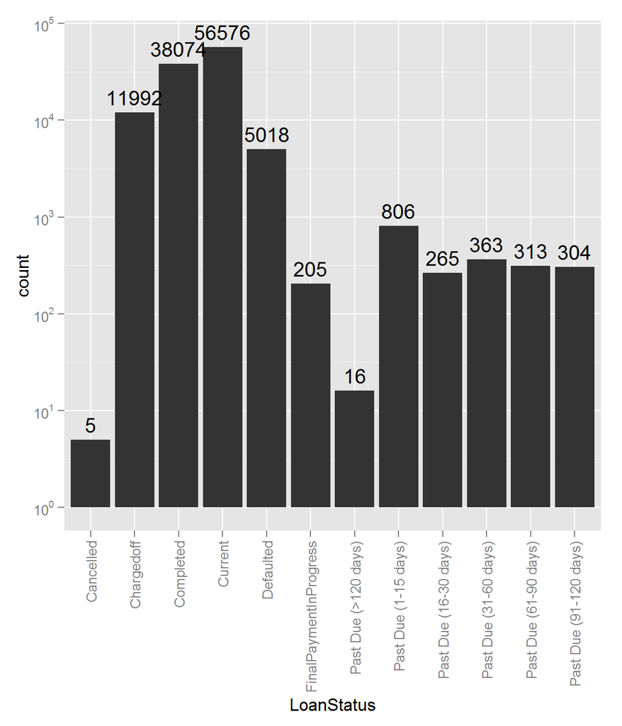

```
##              Cancelled             Chargedoff              Completed
##                      5                  11992                  38074
##                Current              Defaulted FinalPaymentInProgress
##                  56576                   5018                    205
##   Past Due (>120 days)   Past Due (1-15 days)  Past Due (16-30 days)
##                     16                    806                    265
##  Past Due (31-60 days)  Past Due (61-90 days) Past Due (91-120 days)
##                    363                    313                    304
```

By eliminating existing borrowers from the datset,  
* 66% of the borrowers had either already completed the loans or making final payments

- 34% either defaulted/charged off or late in payments

This plot brings encouragement that investing in prosper loans might be an viable investment,  
if we can understand which profiles are likely to default.

Next, let’s review the loan amount requested.

## Loan Original Amount

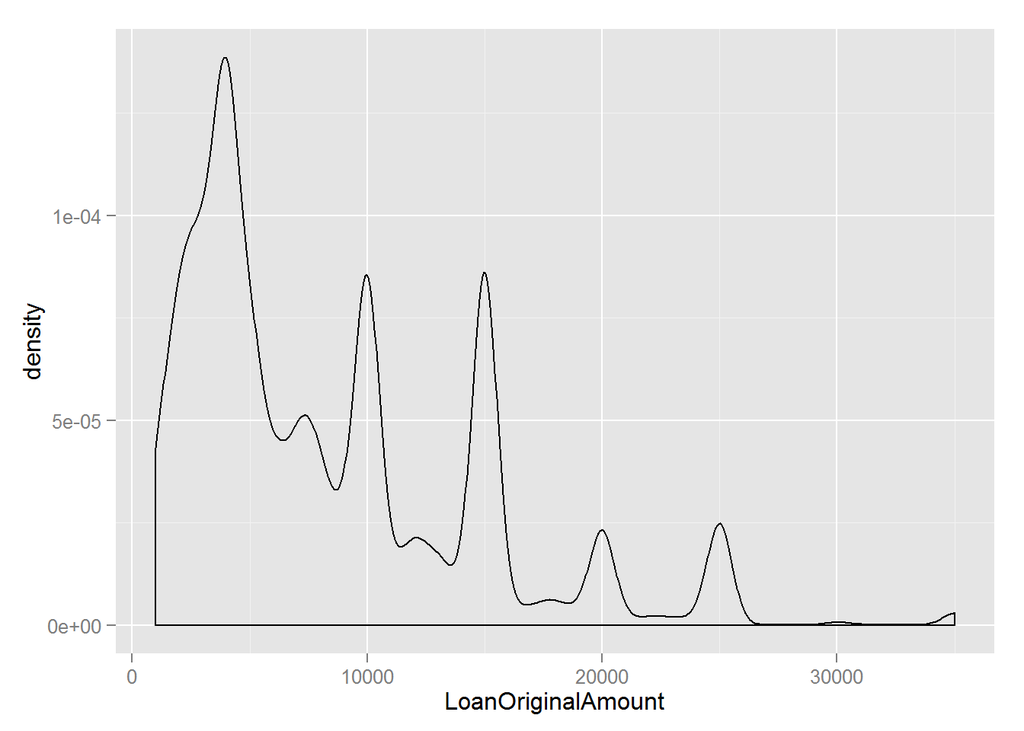

```
##
##  4000 15000 10000  5000  2000  3000
## 14333 12407 11106  6990  6067  5749
```

We can see that most loans taken are about $4000, $15000 ,$10000, $5000, $2000 and $3000.  
This shows that people like to borrow in round amounts.

I feel that the amounts borrowed are not huge and should be manageable if the user have a source of income.

next, let us understand the borrower rate.

## Borrower Rate

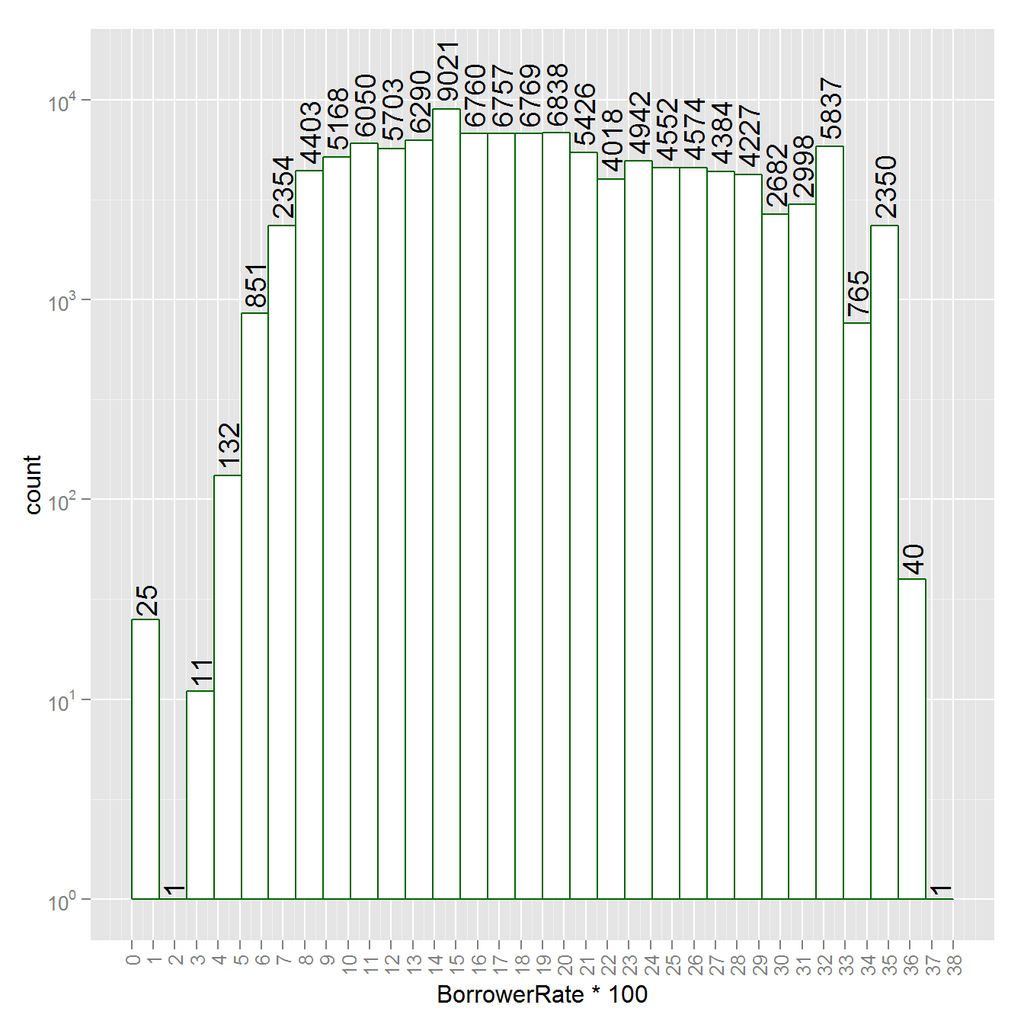

```
##    Min. 1st Qu.  Median    Mean 3rd Qu.    Max.
##  0.0000  0.1340  0.1840  0.1928  0.2500  0.4975
```

## Employment Status

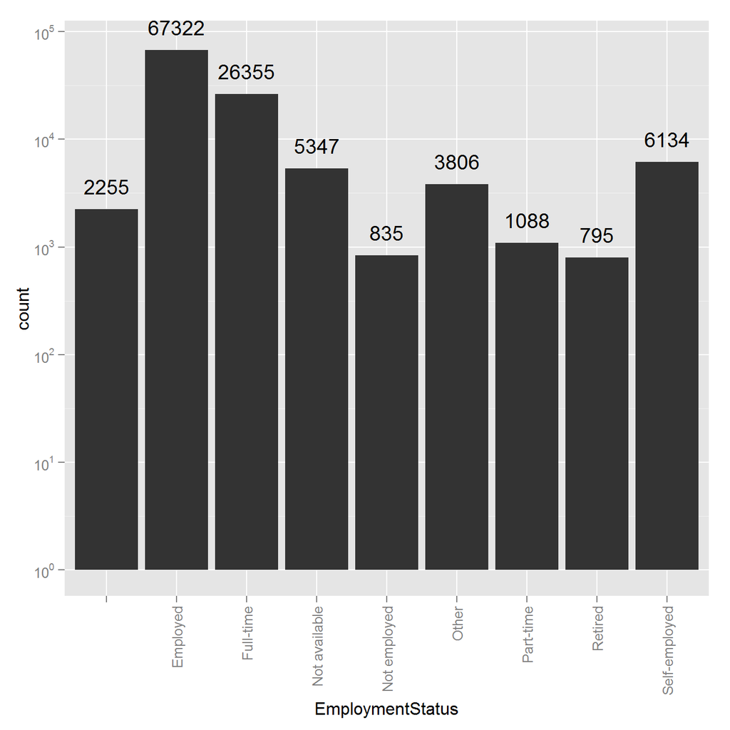

Based on the plot, we can see that

- 2,255 borrowers have no employment status
- 5,347 with employment status as “Not available”
- 835 not employed

Lets check income range of the borrowers in the dataset.

## Income Range - General

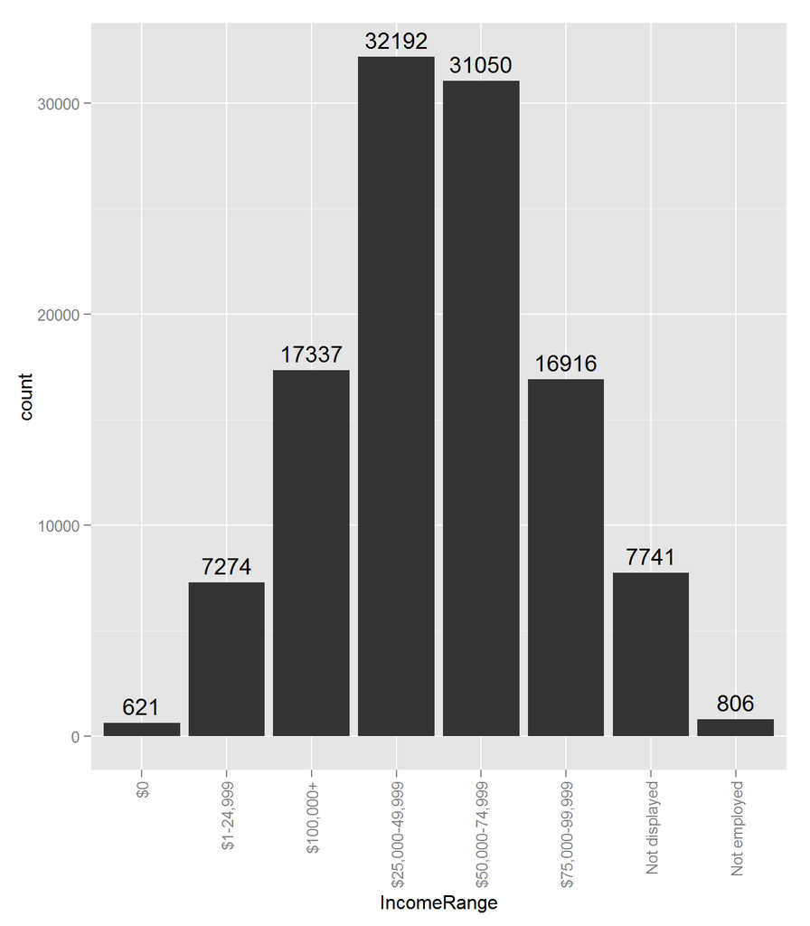

In general,most of the borrower’s income ranges from 25,000 to 75,000.  
It was suprisingly to see 621 borrowers having $0 income obtaining loans.  
Next, let’s review the monthly stated income

## Stated Monthly Income

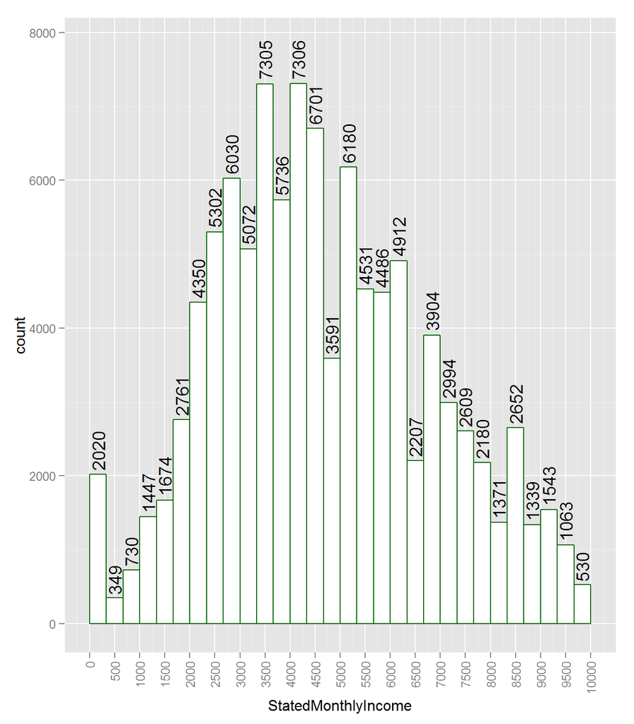

```
##
## 4166.666667        5000 3333.333333        3750 5416.666667 5833.333333
##        3526        3389        2917        2428        2374        2319
```

Most of the borrowers are have stated 3333 to 5833 as their monthly income.

next lets check the creditgrade of the borrowers profile.

## Credit Grade

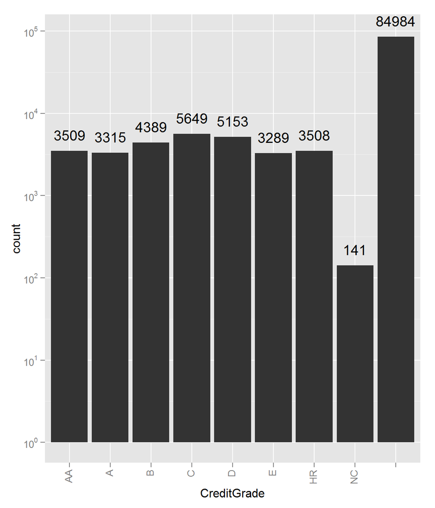

```
##
##           C     D     B    AA    HR
## 84984  5649  5153  4389  3509  3508
```

It has noted that the datafield is populated pre-2009 and only be available for those listing.  
Most of the borrowers are having “C” as creditGrade in the dataset.

so Lets check the ProsperRating..Alpha., which is the field used after jul-2009 to track borrower’s credit rating

## Prosper Loan Rating Alpha

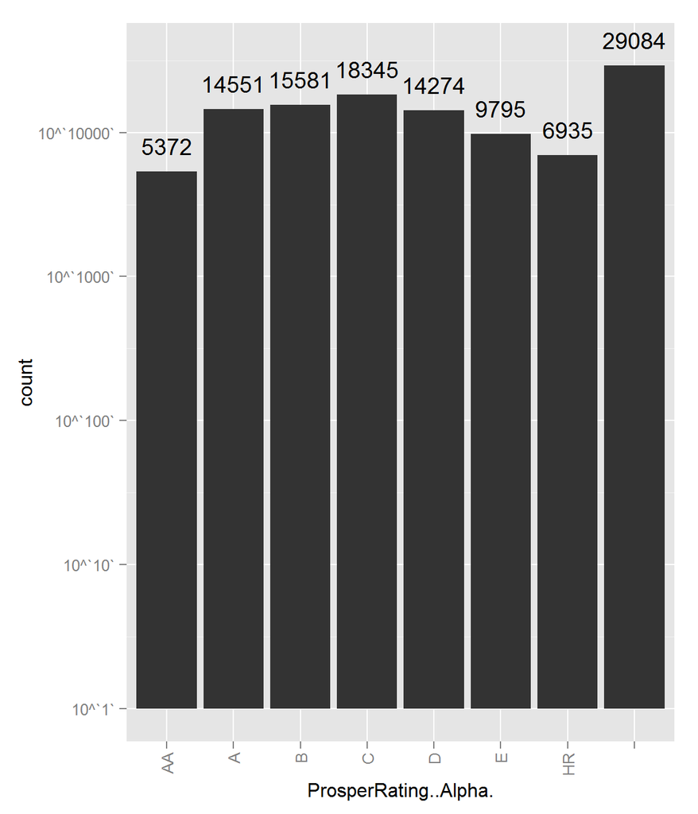

```
##
##           C     B     A     D     E
## 29084 18345 15581 14551 14274  9795
```

```
##
## 2009 2010
##   58   73
```

from the plot we can see that The median prosper rating alpha is C.  
We can see that 29,084 loans are without prosper rating alpha.  
In total 84,853 borrowers are assigned with prosper rating alpha.

Let us check if the borrowers are over-leveraged by checking debit-to-income ratio.

## Debt to Income Ratio

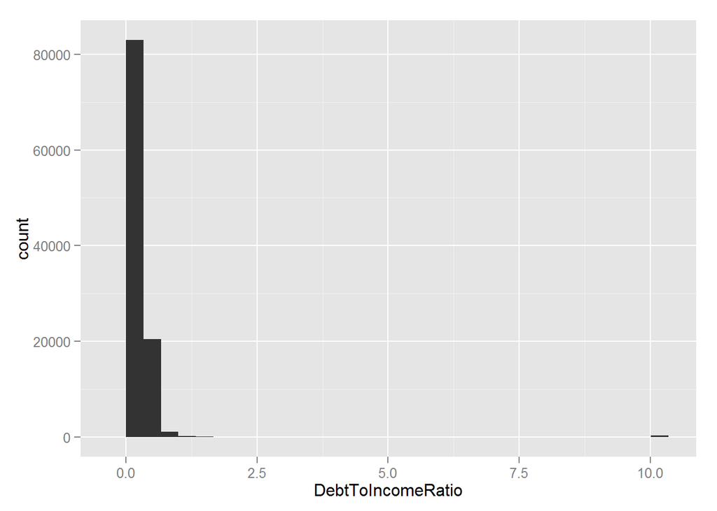

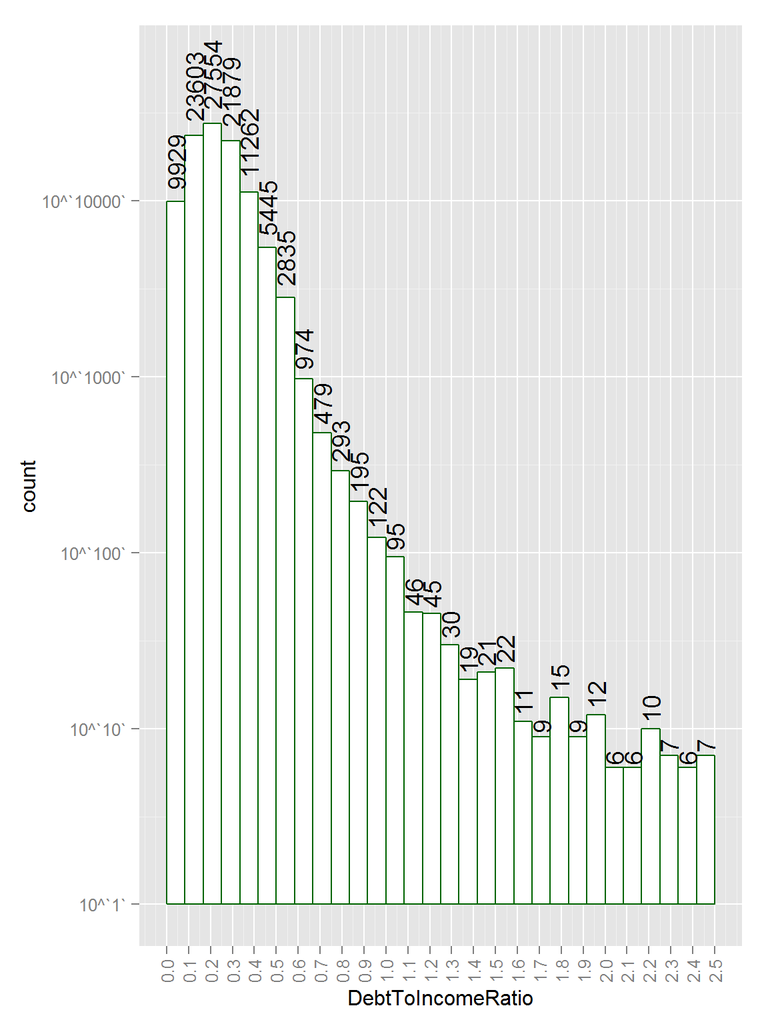

```
##
## 0.18 0.22 0.17 0.14  0.2 0.16
## 4132 3687 3616 3553 3481 3442
```

We can see that most borrowers have debt to income ratio of 0.14 to 0.2.  
I am pleased to see that most borrowers have low debt to income ratio.  
i wonder does low debt to income ratio will correspond with credit grade.

## Term

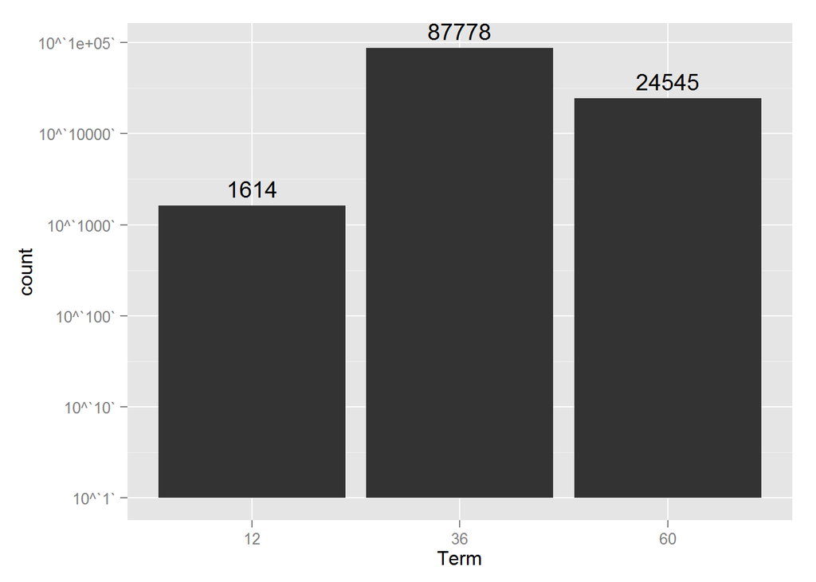

we can see that most of the loans are taken with term of 36 months.  
lets check when the loans happened

## Loan Origination Year

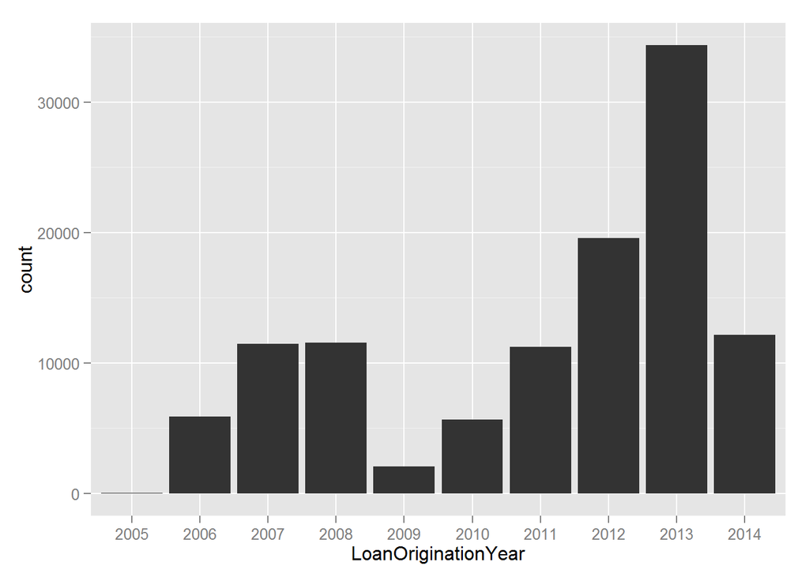

```
##  2005  2006  2007  2008  2009  2010  2011  2012  2013  2014
##    22  5906 11460 11552  2047  5652 11228 19553 34345 12172
```

We can see that there is significant drop in loans taken after 2008.  
After 2009, more people are taking loans.  
let’s check if there is people take more loans in particular months by creating a plot of Loan Oringation Date by formatting the date as month.

## Loan Origination Month

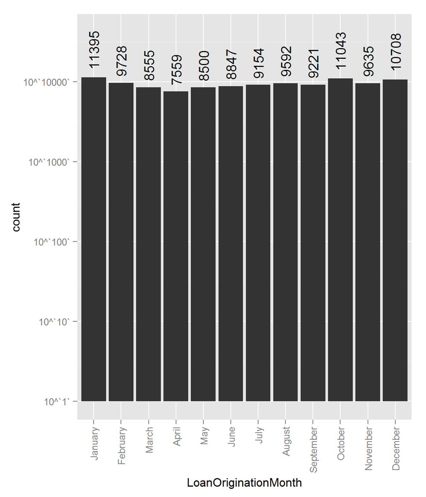

```
##   January  February     March     April       May      June      July
##     11395      9728      8555      7559      8500      8847      9154
##    August September   October  November  December
##      9592      9221     11043      9635     10708
```

We can see that March, April, May has the lowest number of loan taken.  
Borrowers then to take more loans in Janurary and October.  
Let’s check if we modify the loan origination date as month-year date format what will the distribution.

## Loan Origination date as Month-year date format

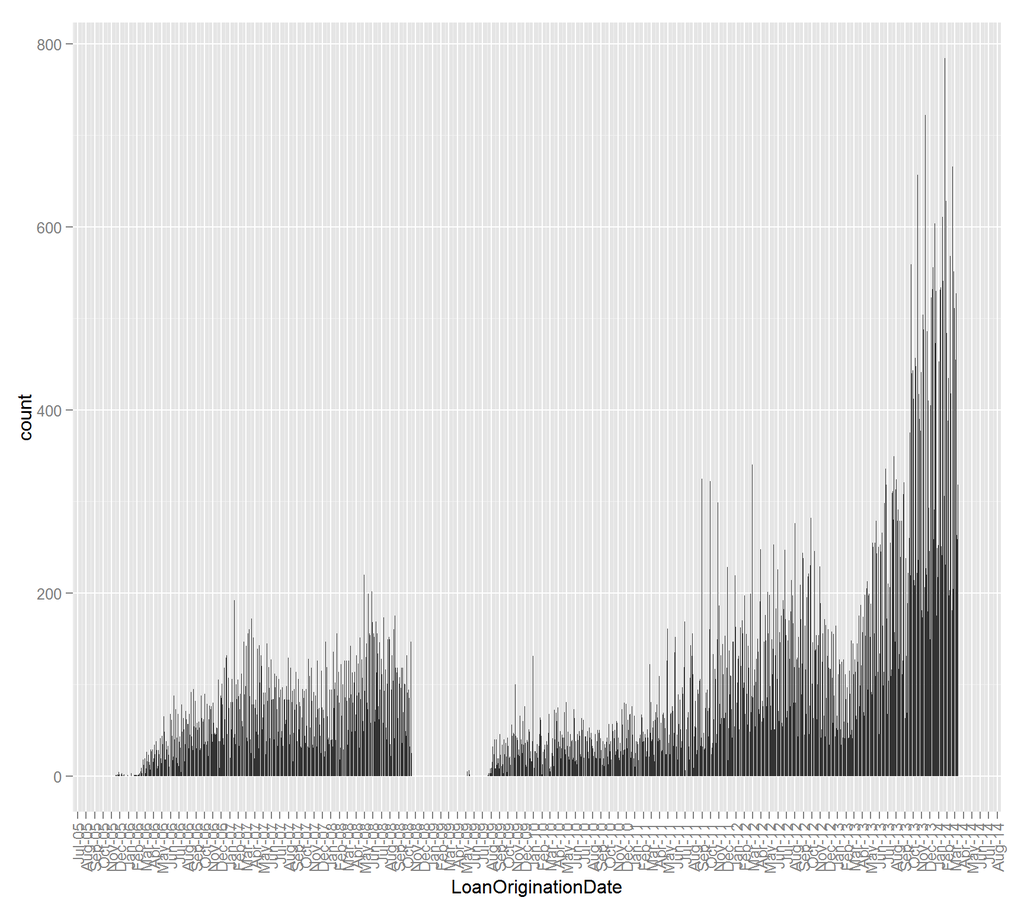

plotting the loan oringination date using month-year format, we can see an increase in loan happened after May 2013.  
I wonder if there was any specifc event that cause the rapid increase of loans taken?  
let check the states where the borrower’s live and their occupation next.

## Borrower State

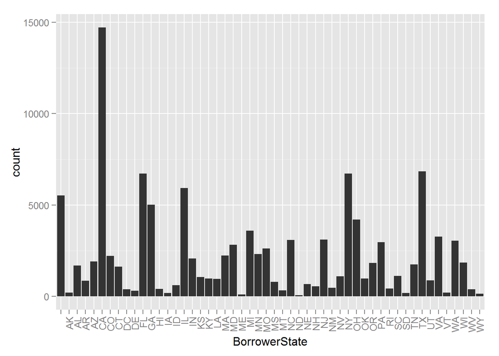

we can see that most of the borrowers live in CA, NY, TX, FL and IL.

## Occupation

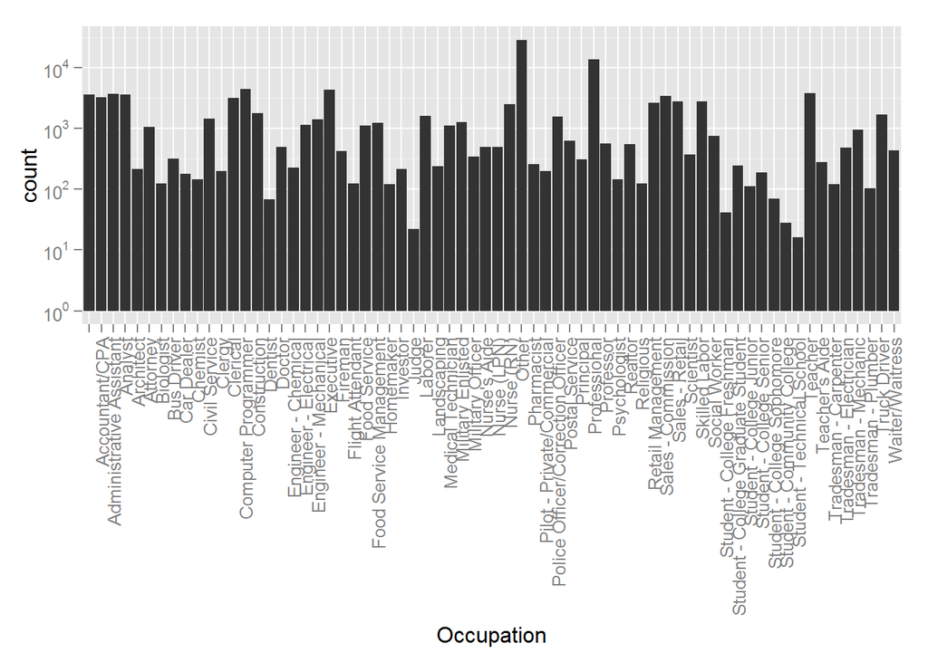

```
##
##                    Other             Professional      Computer Programmer
##                    28617                    13628                     4478
##                Executive                  Teacher Administrative Assistant
##                     4311                     3759                     3688
```

```
##
##  Student - Technical School                       Judge
##                          16                          22
## Student - Community College  Student - College Freshman
##                          28                          41
##                     Dentist Student - College Sophomore
##                          68                          69
```

## Listing Category

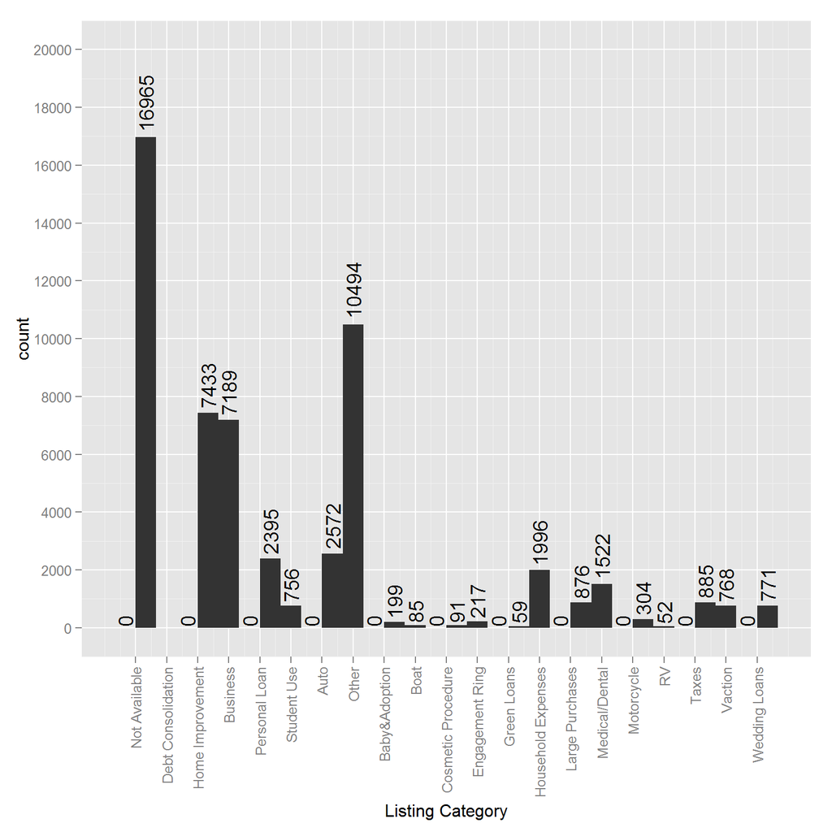

we can see that majority of the loans are for  
* Debt Consolidation (58,308)  
* Others(10,494)  
* Home Improvement (7,433)  
* Business 7189

There is a huge portion (16,965) of the loans with listing status as “Not Available”

## Total Proper Loans

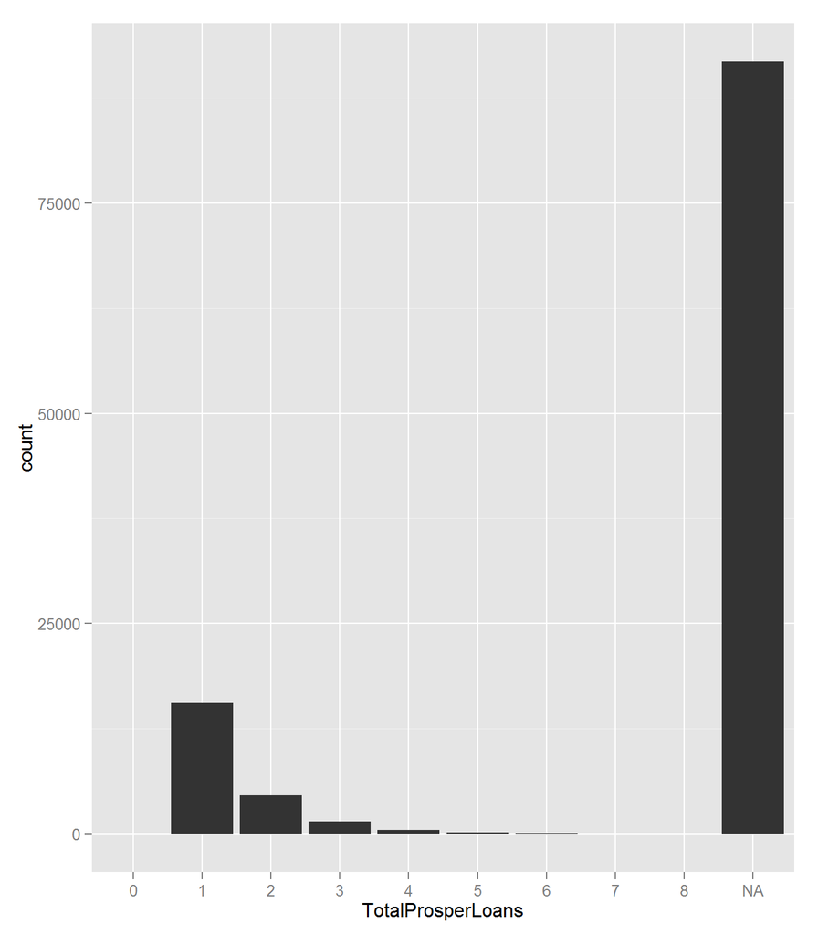

```
##
##     1     2     3     4     5     6     7     0     8
## 15538  4540  1447   417   104    29     8     1     1
```

we can understand from the plot that most of the borrowers have only 1 prosper loan.

# Univariate Analysis

### What is the structure of your dataset?

There are 113,937 listings in the dataset with 83 features.  
I had chosen to analyze the below stated features

- LoanOriginalAmount
- Credit Grade or ProsperRating..Alpha.
- stated monthly income
- Debt to Income Ratio
- Total Prosper Loans
- Current Delinquencies
- Delinquencies past 7 years
- Borrower Rate
- Income Range
- LoanOriginationDate
- Occupation
- Employment Status
- Total Prosper Loans

below describes the ranking of levels of the features explored

(Worst to Best)

Credit Grade : NC HR E D C B A AA

Income Range : * Not employed  
* $0  
* $1-$24,999  
* $25,000-$49,999  
* $50,000 - $74,999  
* $75,000 - $99,999  
* $100,000+  
* Not displayed

ProsperScore Alpha : NC HR E D C B A AA

### What is/are the main feature(s) of interest in your dataset?

The main features of the data set are CreditGrade/Propser Score Alpha, Borrower Rate, Debt to income ratio, Monthly Stated Income and Total prosper loan.

I will want to explore what features will impact the borrower rate.

### What other features in the dataset do you think will help support your investigation into your feature(s) of interest?

I believe related features like Current Delinquencies  
, Delinquencies past 7 years can help support my investigation

### Did you create any new variables from existing variables in the dataset?

I created variable LoanOriginationYear by formatting the LoanOriginationDate to display year.

I create varaible LoanOriginationMOnth by formatting the LoanOriginationDate to display month.

### Of the features you investigated, were there any unusual distributions? Did you perform any operations on the data to tidy, adjust, or change the form of the data? If so, why did you do this?

I found that feature Loan Orgination date has unusual distribution.

when ploting the Loan Origination month histogram,  
i can see a slight “concave” distribution.  
Therefore, i converted the month into month-year date format and re-plotted the histogram.  
We can now see that the month-year date format depicts distribution skewed towards the right.  
We can determine that there was an increased amount of loans are taken May 2013.

# Bivariate Plots Section

to get an overview of the relationship between identified featuresets,  
i use ggpairs to generate a summary of plots of features on a small sample size of 10,000 records.

## Correlation Analysis

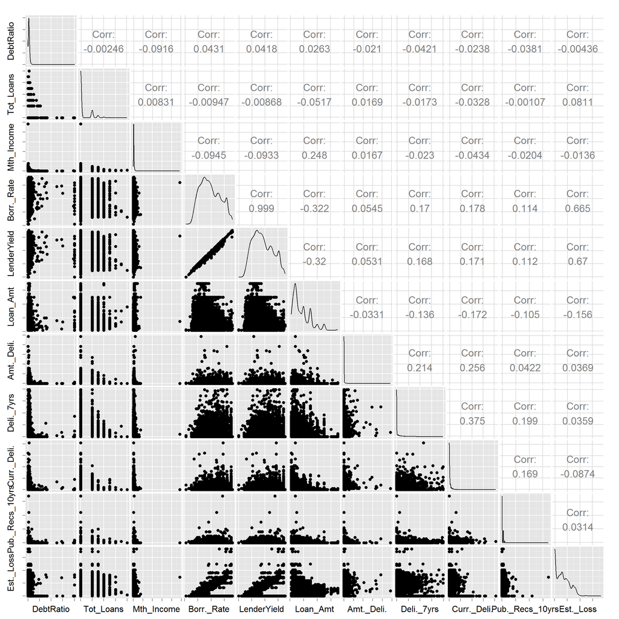

```
##                    DebtRatio    Tot_Loans   Mth_Income  Borr._Rate
## DebtRatio        1.000000000 -0.002460505 -0.091592012  0.04314857
## Tot_Loans       -0.002460505  1.000000000  0.008312268 -0.00946984
## Mth_Income      -0.091592012  0.008312268  1.000000000 -0.09446950
## Borr._Rate       0.043148566 -0.009469840 -0.094469498  1.00000000
## LenderYield      0.041770598 -0.008676489 -0.093319765  0.99909658
## Loan_Amt         0.026265357 -0.051715367  0.247847314 -0.32174419
## Amt._Deli.      -0.021032613  0.016874750  0.016731934  0.05452406
## Deli._7yrs      -0.042052752 -0.017348808 -0.023012908  0.17039775
## Curr._Deli.     -0.023802508 -0.032839024 -0.043412735  0.17832960
## Pub._Recs_10yrs -0.038074820 -0.001069902 -0.020373066  0.11417204
## Est._Loss       -0.004362591  0.081068110 -0.013598529  0.66535681
##                  LenderYield    Loan_Amt  Amt._Deli.  Deli._7yrs
## DebtRatio        0.041770598  0.02626536 -0.02103261 -0.04205275
## Tot_Loans       -0.008676489 -0.05171537  0.01687475 -0.01734881
## Mth_Income      -0.093319765  0.24784731  0.01673193 -0.02301291
## Borr._Rate       0.999096577 -0.32174419  0.05452406  0.17039775
## LenderYield      1.000000000 -0.32024741  0.05313770  0.16767690
## Loan_Amt        -0.320247408  1.00000000 -0.03311108 -0.13592398
## Amt._Deli.       0.053137697 -0.03311108  1.00000000  0.21398592
## Deli._7yrs       0.167676902 -0.13592398  0.21398592  1.00000000
## Curr._Deli.      0.171173360 -0.17222498  0.25581540  0.37506143
## Pub._Recs_10yrs  0.112169959 -0.10484178  0.04218390  0.19930894
## Est._Loss        0.669757203 -0.15604049  0.03686975  0.03585957
##                 Curr._Deli. Pub._Recs_10yrs    Est._Loss
## DebtRatio       -0.02380251    -0.038074820 -0.004362591
## Tot_Loans       -0.03283902    -0.001069902  0.081068110
## Mth_Income      -0.04341274    -0.020373066 -0.013598529
## Borr._Rate       0.17832960     0.114172036  0.665356813
## LenderYield      0.17117336     0.112169959  0.669757203
## Loan_Amt        -0.17222498    -0.104841778 -0.156040491
## Amt._Deli.       0.25581540     0.042183896  0.036869751
## Deli._7yrs       0.37506143     0.199308940  0.035859567
## Curr._Deli.      1.00000000     0.169319858 -0.087371757
## Pub._Recs_10yrs  0.16931986     1.000000000  0.031380880
## Est._Loss       -0.08737176     0.031380880  1.000000000
```

let’s focus on borrowers income range for borrowers with emmployment status as “not employed” or “no employment status”.

## Income Range - employment status = Not Employed or Not available

```
## [1] ""              "Employed"      "Full-time"     "Not available"
## [5] "Not employed"  "Other"         "Part-time"     "Retired"
## [9] "Self-employed"
```

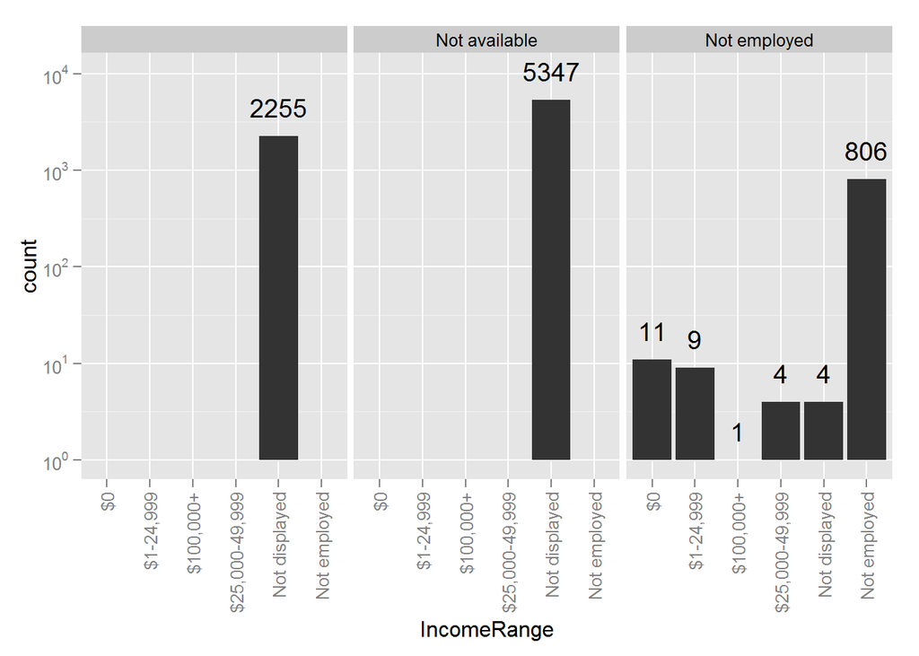

if we subset the data for those borrowers without employment status or not available and or employed, we uncover some interesting details.

there are 11 people in this group declared they have $0 as well as having employment status as not employed obtaining loans.

there are 806 people in this group declared their income range as “not employed”" for income range as well as not employed obtaining loans.

Most of the people with income range status as “Not displayed” come from the group of people declaring their employment status as (no employment status/not available or not employed).

I wanted to know if term changes with the loan amount and decided to do a violin plot to understand the distribution.

## Term vs Loan Original Amount

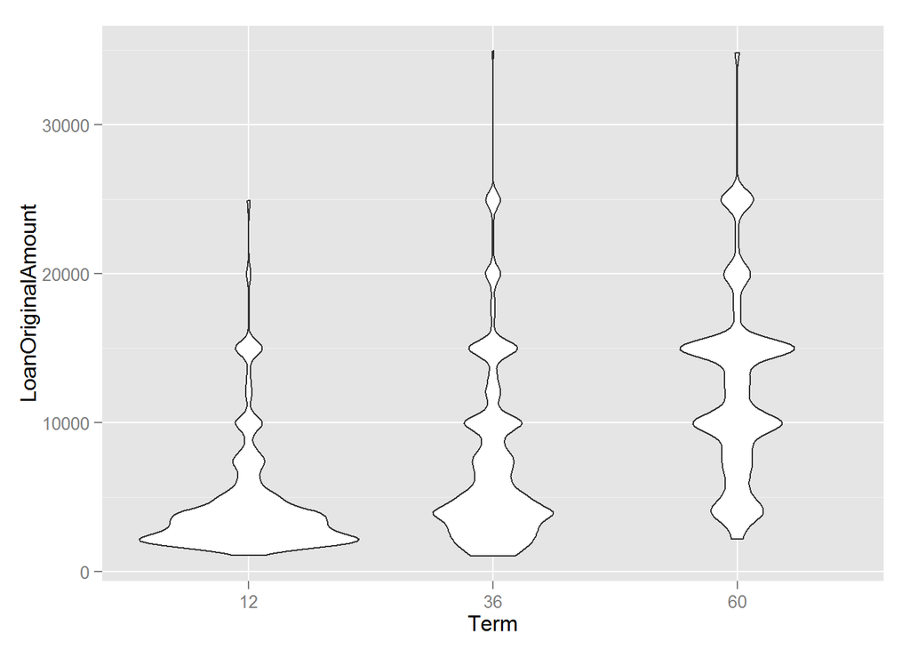

```
##   Term  freq
## 1   12  1614
## 2   36 87778
## 3   60 24545
```

```
##   Term LoanOriginalAmount  freq
## 1   36               4000 12088
## 2   36              10000  7049
## 3   36              15000  6674
## 4   36               5000  6169
## 5   60              15000  5668
## 6   36               2000  5336
```

we can see that for loan amounts under 10,000, the term varies widely.  
for loans above 30,000, we can see the term varies little.

by constructing a frequency table by term, we can see that most people opt for 36 months loans, followed by 60 months loan.

by constructing a frequency table by term and loan amount, we can see that most people opt for 36 months loans for loan of 4,000 and followed by 36 months loan for loan of 10,000.

Let’s check the correlation between Term and Loan Original Amount is

```
## [1] 0.3389275
```

## Loan Origination Year Vs Loan Original Amount

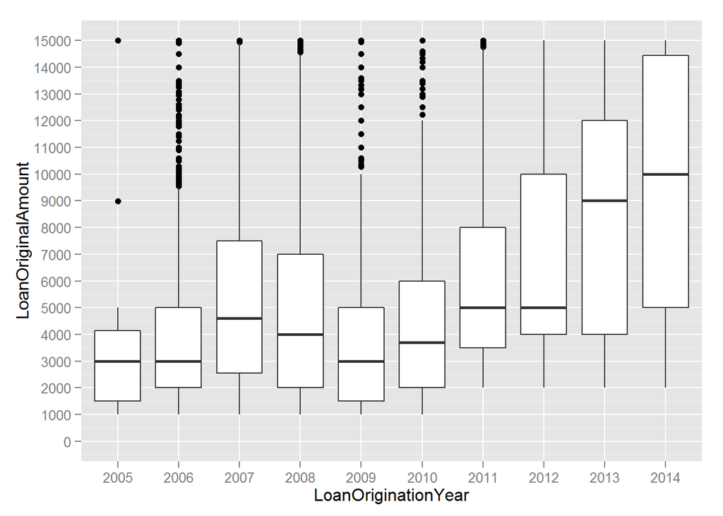

```
##   LoanOriginationYear LoanOriginalAmount freq
## 1                2013              15000 5954
## 2                2013               4000 5869
## 3                2013              10000 5648
## 4                2012               4000 4383
## 5                2014              15000 2441
## 6                2012              15000 2200
```

```
##   LoanOriginationYear LoanOriginalAmount freq
## 1                2008               5000 1153
## 2                2008               1000 1121
## 3                2007               5000 1085
## 4                2008               3000  859
## 5                2007               3000  747
## 6                2007               1000  680
```

We can see that range of loans amount increases after 2011.  
Most loan amounts requested  
* are 15,000, 4,000 and 10,000 after 2011.  
* are 5000 and 1000 before 2011.

Let’s check the correlation between Loan Origination Year and Loan Original Amount is

```
## [1] 0.3107383
```

i am curious to understand which state does the bulk of the borrowers reside in.

## Borrower State

```
##             state  freq
## 5      california 14717
## 43          texas  6842
## 32       new york  6729
## 9         florida  6720
## 13       illinois  5921
## 51           <NA>  5897
## 10        georgia  5008
## 35           ohio  4197
## 22       michigan  3593
## 46       virginia  3278
## 30     new jersey  3097
## 33 north carolina  3084
## 47     washington  3048
## 38   pennsylvania  2972
```

[output cut: 37 more lines]

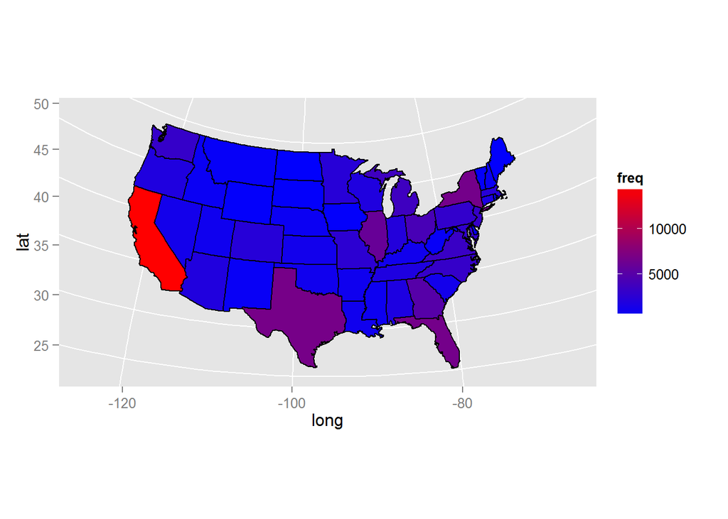

```
##       region  freq
## 1 california 14717
## 2      texas  6842
## 3   new york  6729
## 4    florida  6720
## 5   illinois  5921
## 6    georgia  5008
```

It is clear that the bulk of borrowers live in California, Texas, New York Florida and Illinois.

States like Montana, Wyomin, North Dakota, South Dakota and Maine has the least amnount of borrowers.

I am curious to see the distribution of credit grade and loan amounts of borrowers living in California, Texas, New York Florida and Illinois.

## Stated Monthly Income by BorrowerState

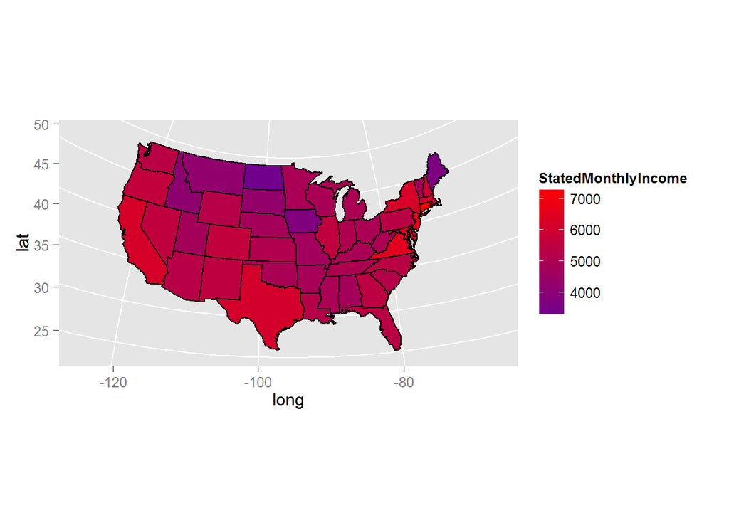

```
##          region StatedMonthlyIncome
## 1   connecticut            7394.697
## 2    new jersey            6807.020
## 3      maryland            6516.032
## 4      virginia            6508.574
## 5      new york            6225.881
## 6 massachusetts            6190.190
```

We can see that Connecticut, New Jersey, Maryland, Virginia and New York are the top 5 states with highest mean stated Monthly income.  
When we compare with the number of loans taken (where the bulk of borrowers live in California, Texas, New York, Florida and Illinois)  
we do not see there is a 100% correlation between top 5 loans borrowed by state vs top 5 mean statedMonthlyIncome by state.

If we check the state population estimate as of 1st July 2014 from wikipedia, we can see that the top 5 states with the biggest population corresponds with the top 5 states with number of loans.

## Borrower State ( CA, TX, NY, IL, FL ) and Percentage of CreditGrade

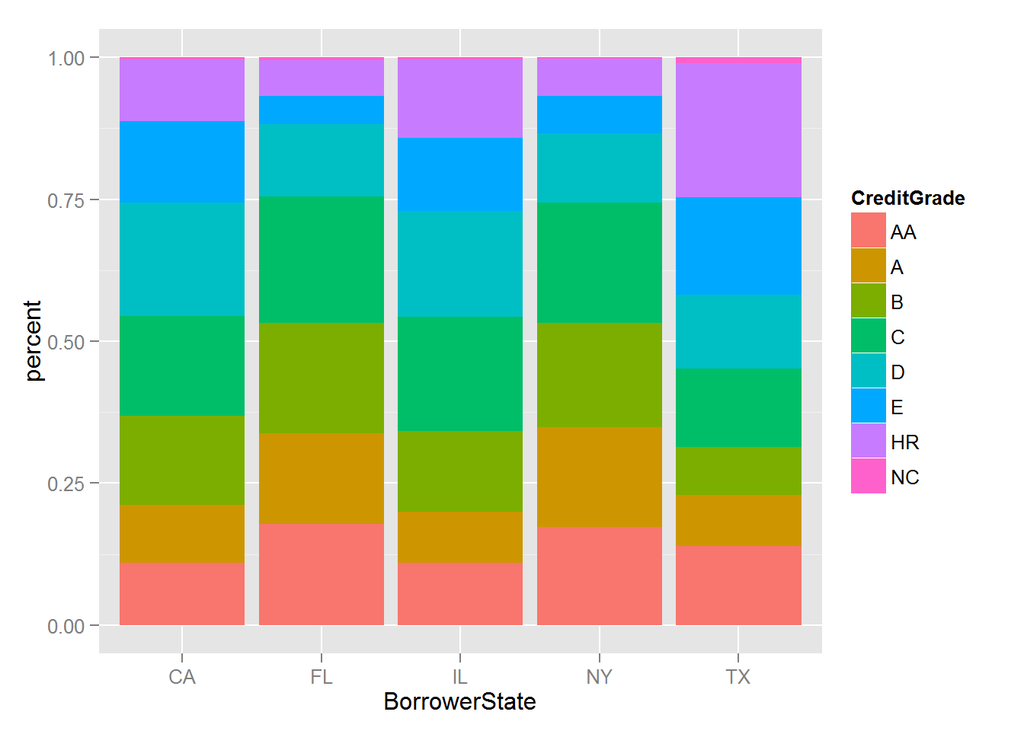

```
##    CreditGrade BorrowerState r_state_tot r_state_amt_tot
## 1           AA            CA        3938        28747541
## 2            A            CA        3938        28747541
## 3           AA            FL        1310         8827722
## 4            A            FL        1310         8827722
## 5           AA            IL        1650        10108612
## 6            A            IL        1650        10108612
## 7           AA            NY         876         5475925
## 8            A            NY         876         5475925
## 9           AA            TX        1190         6846539
## 10           A            TX        1190         6846539
##    r_state_CrGrade_tot r_state_CrGrade_amt_tot    percent percent_amt
## 1                  430                 4644285 0.10919248   0.1615542
## 2                  405                 4478853 0.10284408   0.1557995
## 3                  233                 2446178 0.17786260   0.2771018
## 4                  210                 2010571 0.16030534   0.2277565
## 5                  182                 1763967 0.11030303   0.1745014
## 6                  147                 1586801 0.08909091   0.1569752
## 7                  151                 1374195 0.17237443   0.2509521
## 8                  154                 1316122 0.17579909   0.2403470
## 9                  166                 1257019 0.13949580   0.1835992
## 10                 106                 1023284 0.08907563   0.1494600
```

New York has the highest percentage of borrowers with credit grade of AA and A, and i suspect that people there has better paying jobs then rest of the states in the histogram.

## Credit Grade vs Loan Original Amount, Proper Rating Alpha vs Loan Amounts

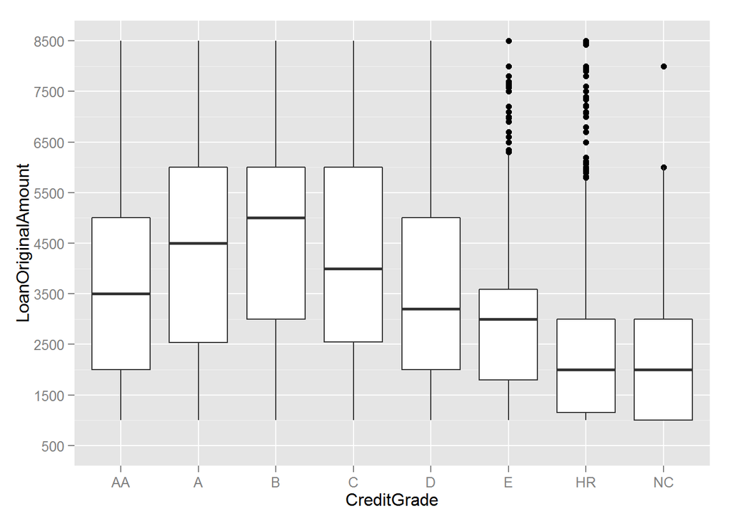

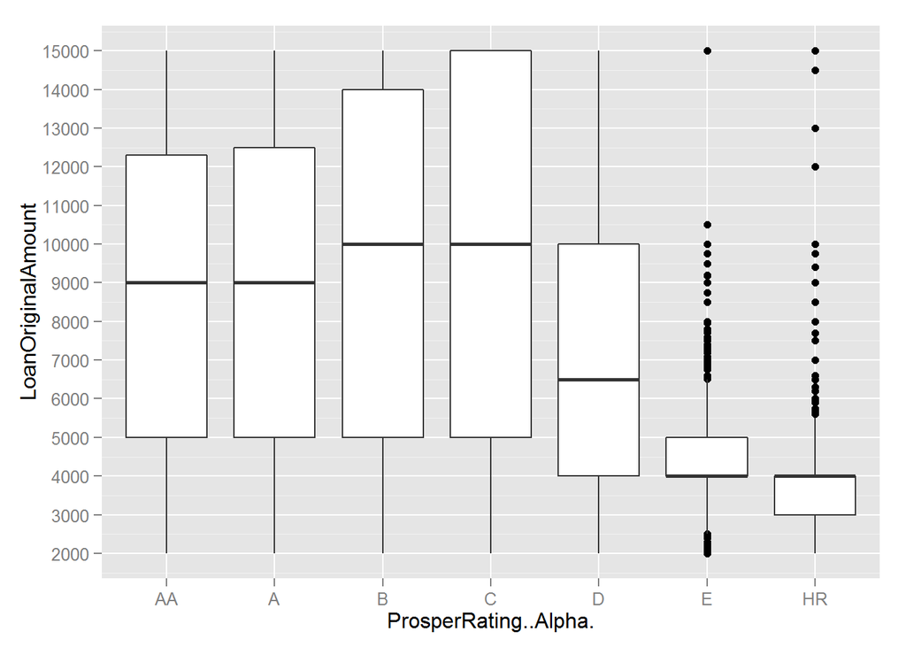

In general, we can confirm that people with higher credit grade will be able to obtain higher loan amounts.

## Credit Grade/ProsperRating..Alpha. vs BorrowerRate

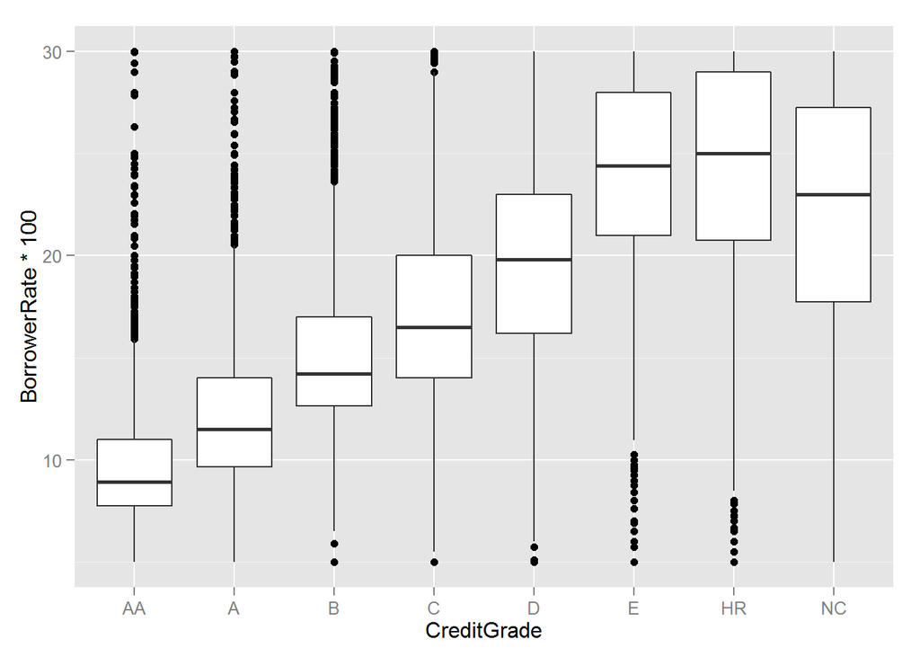

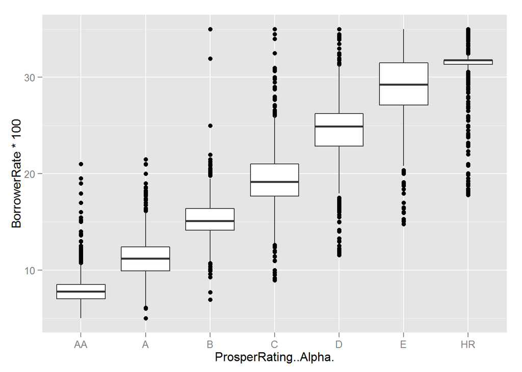

by plotting GreditGrade versus Borrower Rate we can see that borrowers with lower credit grade paid more interest as compared with borrowers with higher credit grade. for borrowers with lower creditgrade the Borrower Rates varies wider as compared with those having a better creditgrade.

Let’s check the correlation between Credit Grade and Borrower Rate is

```
## [1] 0.2077615
```

Let’s check the correlation between ProsperRating..Alpha. and Borrower Rate is

```
## [1] 0.3862702
```

we do see an increase in correlation for borrower rate after Prosper Rating Alpha was introduced.

## Employment Status vs BorrowerRate

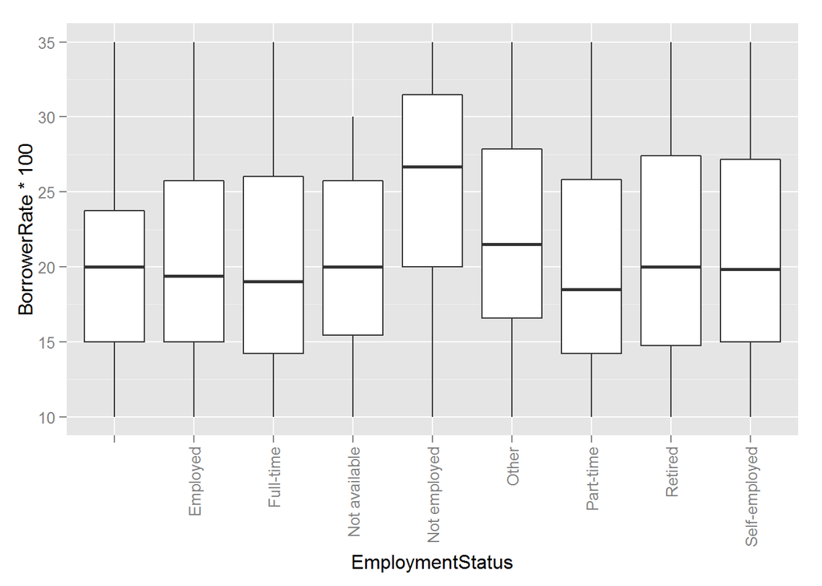

We can see that borrowers that are “Not Employed” and “Other” have a higher borrower rate ( greater than 20%) as compared with other employment status.

Let’s check the correlation between Employement Status and Borrower Rate is

```
## [1] 0.04313998
```

there is a weak correlation between employment status and borrower rate.  
I think maybe employment status is a factor used to compute credit grade or prosper rating alpha, therefore the correlation is low.

# Bivariate Analysis

### Talk about some of the relationships you observed in this part of the investigation. How did the feature(s) of interest vary with other features in the dataset?

we can see that the range of loan amounts increases after 2011

There is a linear relationship between borrower rate and lender yield, increase in borrower rate corresponds with an increase with lender yield.

we can also see that borrowers with the Best credit grade enjoy lowest borrower rate.

### Did you observe any interesting relationships between the other features (not the main feature(s) of interest)?

In the plot of BorrowerState vs CreditGrade, we can observe that people in NY has better credit grade than the rest of the states ( CA, FL, IL, TX)

### What was the strongest relationship you found?

the strongest relationships i found is between borrower yield and lender rate they have the correlation of 99.9%

# Multivariate Plots Section

Let us check the distirbution of loan amounts by Credit Grade and borrower State for (CA, TX, NY, IL, FL)

## Borrower State ( CA, TX, NY, IL, FL ) and CreditGrade and Percentage of Loan Amount

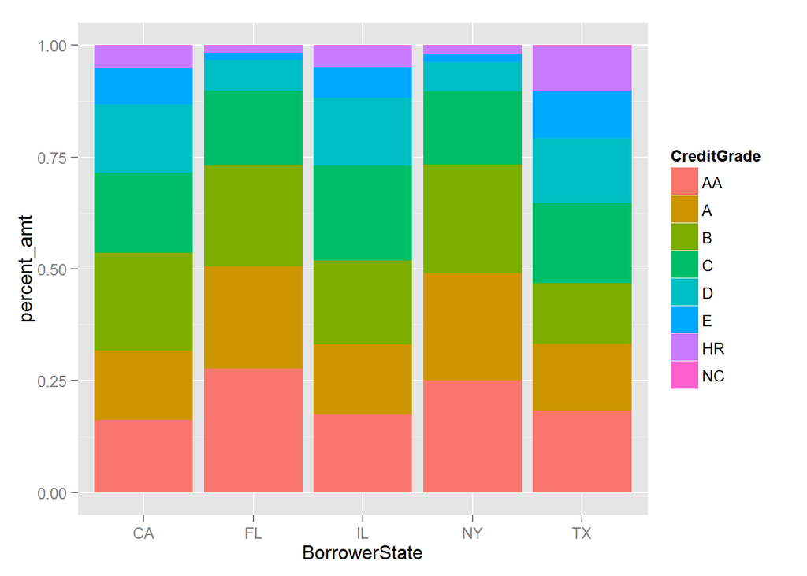

```
##   CreditGrade BorrowerState r_state_tot r_state_amt_tot
## 1          AA            CA        3938        28747541
## 2           A            CA        3938        28747541
## 3           B            CA        3938        28747541
## 4           C            CA        3938        28747541
## 5           D            CA        3938        28747541
## 6           E            CA        3938        28747541
##   r_state_CrGrade_tot r_state_CrGrade_amt_tot   percent percent_amt
## 1                 430                 4644285 0.1091925  0.16155417
## 2                 405                 4478853 0.1028441  0.15579952
## 3                 618                 6307155 0.1569325  0.21939807
## 4                 692                 5105296 0.1757237  0.17759070
## 5                 786                 4420262 0.1995937  0.15376139
## 6                 565                 2323897 0.1434738  0.08083811
```

We can see that in terms of credit grade and loan amount percentage Florida and New York have almost the same distribution.

Next let us check the borrower Rate vs Credit Grade by IncomeRange